# London House Price visualisations

#This notebook contains visualisations relating to London House prices including maps created using a GeoJSON file

## Install packages

install.packages(“rgdal”)  
install.packages(“leaflet”)  
install.packages(“geojsonio”)  
install.packages(“e1071”)  
install.packages(“shapefiles”)  
install.packages(“sf”)  
install.packages(“StatMeasures”)  
install.packages(“gridExtra”)  
install.packages(“viridis”)  
install.packages(“hrbrthemes”)

## Load libraries

library(tidyverse)  
library(dplyr)  
library(ggplot2)  
library(ggridges)  
library(rgdal)  
library(leaflet)  
library(“shapefiles”)  
library(“sf”)  
library(“StatMeasures”)  
library(“gridExtra”)  
library(“lubridate”)  
library(“viridis”)  
library(“hrbrthemes”)

## Load data

#Read Big ppdata_lite file  
df <- read.csv(“/Users/chloemaine/Documents/Chloe/BGSE/data_vis_t2/arapakis/mini_project/ppdata_lite.csv”)

#Read UK postocdes  
postcodes <- read.csv(“/Users/chloemaine/Documents/Chloe/BGSE/data_vis_t2/arapakis/mini_project/ukpostcodes.csv”)

#Read UK districts shape polygon file  
districts <- st_read(“/Users/chloemaine/Documents/Chloe/BGSE/data_vis_t2/arapakis/mini_project/Distribution/Districts.shx”)

## Data pre-processing

#Filter data to Greater london only  
col_names <- colnames(df)  
my_data <- subset.data.frame(df, county == “GREATER LONDON”)

#Create df  
my_df = data.frame(nrows = dim(my_data)[1])  
for (col in col_names) {  
my_df <- cbind(my_df, my_data[col]) }

#Convert price in £ to price in £k  
my_df$pricex <- my_df$price /1000

## 1: House price box plots of London by borough

#Group by borough  
boroughs <- group_by(my_df, district)  
boroughs_mutated <- boroughs

### 1.a Box plots of price by borough

ggplot(boroughs_mutated,  
aes(x = reorder(district, price, FUN = median), # Reorder house price medians  
y = pricex , group = district)) +  
geom_boxplot(lwd = 0.5, outlier.size = 0.1, fill= " light blue“) + # Change colouring  
stat_boxplot(geom =‘errorbar’) +  
ylim(0,1000) +  
coord_flip() + # Improve readability of borough  
theme_minimal() +  
xlab(”Borough“) +  
ylab(”Price £k“) +  
ggtitle(”House price by borough“) +  
theme(plot.title = element_text(size = 16, face =”bold"))

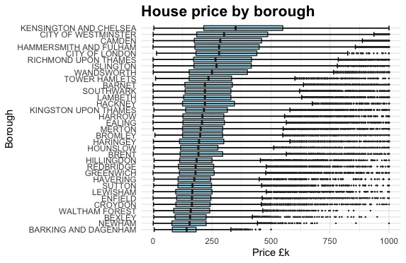

.

```
Here I plot the distribution of house prices by borough using a box plot. Key 3 features of this plot are:
- To improve readability, I have flipped the coordinate axes so that names are visible in the horizontal and plotted house price in £k rather than £
- Ordering the boroughs by house price median improves the appearance and makes the quartile patterns immediately obvious.
- Playing with boxplot and gridline colouring yields (what I hope is!) an attractive plot.
```

### 1.b. Geom density ridges

ggplot(boroughs_mutated,  
aes(x= price_x, y = reorder(district, price, FUN = median), # As above, reorder medians  
fill = stat(x))) +  
geom_density_ridges_gradient(scale = 2, rel_min_height = 0.01, quantile_lines=TRUE, calc_ecdf = TRUE, quantiles = 2, # Add median line to each plot colour = “white”) + # Vis- appealing white outline  
labs(title = ‘House prices by borough’) +  
scale_x_continuous(limits = c(0, 750)) +  
xlab(“Price £k”) +  
ylab(“Borough”) +  
scale_point_color_hue(l=40) +  
theme_minimal() +  
theme(legend.position=“none”,  
panel.grid.major.x = element_line(colour = “dark blue”), # Change horiz. gridlines  
plot.title = element_text(size = 16, face = “bold”))

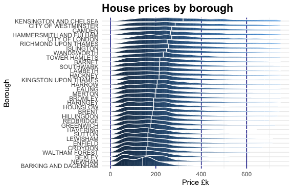

.

```
An alternative way to demonstrate how prices vary by borough in London is through geom_density_ridges, which gives a better idea of the overall density distribution (especially in cases where the data is multi-modal) but is more difficult to see the actual values in a given distribution. Key feature…
 - As above, boroughs ordered by their median
 - The white outline surrounding the ridge, which is visually appealing
 - Add median line to each ridge (I could have chosen additional quartiles but this looked too fussy)
  - Navy blue bold vertical gridlines but soft horizontal gridlines to emphasise the price £k values but not overpower the distribution itself on the horizontal axis.
```

## 2. House price by floor level

#Select only the properties labeled as flats  
flats <- subset(my_df, my_df$property_type == "F" & !(my_df$SAON == ""))

#Retain only the numeric values of the field SAON  
flats$SAON <- gsub('\\D+','', flats$SAON)  
flats$floor <- as.numeric(flats$SAON)  
flats$price_x <- flats$price /1000

#Assume that there are very few buildings with 15+ floors in London; #Hence recursively remove right hand side number until SAON <= 15 and assume this is floor  
for (i in 1:10) {  
flats$floor <- ifelse(flats$floor > 15, substr(flats$floor, 1, (nchar(flats$floor)-1)), flats$floor) <br /> flats$floor <- as.numeric(flats$floor) }

[output not shown]

ggplot(flats,  
aes(x=factor(floor), y = price_x)) +  
geom_violin(draw_quantiles = c(0.2, 0.4, 0.6, 0.8),  
fill = “brown 2”, colour= “navyblue” ) +  
ylim(0,1000) +  
xlab(“Floor”) +  
ylab(“Price £k”) +  
theme_classic() +  
ggtitle(“House price by floor”) +  
theme(plot.title = element_text(size = 16, face = “bold”))

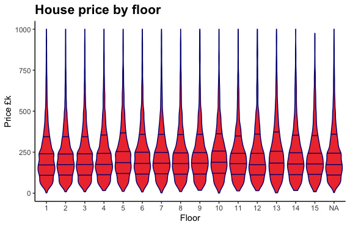

.

```
Here I chose to plot house price by floor using a violin plot. As there do not appear to be significant differences in house price by floor, this plot does not convey a key trend or message. Nonetheless, this information is informative in and of itself.
```

### Create GeoJSON file

```
Here I create a GeoJSON file. The steps I take are as follows:
 - Create summary dataframe by postcode showing the max, median, min and mean house prices.
  - Merge with the postcode file supplied.
  - Convert to SpatialPointsDataFrame and save as GeoJSON.

I also chose to merge the dataframe with a shape polygon file, which enables the plotting of district boundaries. The reason for doing this is to allow colouring of individual districts rather than just specific points.
- This required extracting the district code from the postcode.
```

## 3. Price by district maps

#Summarise price data by postcode  
geo_df = my_data %>%  
group_by(postcode) %>%  
summarize(price_max = max(price), na.rm = TRUE,  
price_median = median(price), na.rm = TRUE,  
price_min = min(price), na.rm = TRUE,  
price_mean = mean(price), na.rm = TRUE)

#Merge price data with postcode latitude and longitude  
geo_df <- merge(geo_df, postcodes ,by=“postcode”)

#Geo_df is a dataframe with coordinates on cols 8 (LATITUDE) and 9 (LONGITUDE) #Transfer coordinates to numeric  
geo_df$latitude <- as.numeric(geo_df$latitude)  
geo_df$longitude <- as.numeric(geo_df$longitude)

#Convert to class SpatialPointsDataFrame  
geo_df.SP <- SpatialPointsDataFrame(geo_df[,c(8,9)], geo_df[,-c(8,9)])  
str(geo_df.SP)

#Write as geojson  
writeOGR(geo_df.SP, ‘geo_df.geojson’,‘dataMap’, driver=‘GeoJSON’)

#If desired, load as geojson #loaded_geo_df <- rgdal::readOGR(“/Users/chloemaine/Documents/Chloe/BGSE/data_vis_t2/mini_project/geo_df.geojson”)

### Prepare district polygon data for plotting

#Prepare summary dataframe containing median, mean, max, min #Separate out postcode into district code and local code to enable matching with #shape polygon file  
dist_df = df %>%  
separate(postcode, c(“pc1”, “pc2”), sep = " ") %>%  
group_by(pc1) %>%  
summarize(price_max = max(price_x), na.rm = FALSE,  
price_median = median(price_x), na.rm = FALSE,  
price_min = min(price_x), na.rm = FALSE,  
price_mean = mean(price_x), na.rm = FALSE)

#Calculate which decile of all UK house district house price medians and means #each district falls into #This allows neat plotting by decile  
med_deciles <- decile(dist_df$price_median) <br />mean_deciles <- decile(dist_df$price_mean)

#Bind deciles to df  
dist_df <- cbind(dist_df, med_deciles)  
dist_df <- cbind(dist_df, mean_deciles)

#Merge calculated district code with shape polygon file  
dist_df <- merge(dist_df, districts , by.x = c(“pc1”), by.y=c(“name”))

p1 <- ggplot(dist_df$geometry) + <br /> geom_sf(aes(fill = dist_df$med_deciles),  
size = 0.0001,  
color=“dark blue”) +  
scale_fill_viridis_c( name = “Decile”) +  
theme_minimal() +  
theme(legend.title = element_text(colour=“black”, size=8, face=“bold”),  
legend.position=“bottom”,  
axis.title.x=element_blank(),  
axis.text.x=element_blank(),  
axis.ticks.x=element_blank(),  
axis.title.y=element_blank(),  
axis.text.y=element_blank(),  
axis.ticks.y=element_blank(),  
panel.grid.major = element_blank(),  
plot.title = element_text(size = 16, face = “bold”)) +  
ggtitle(“Median House Prices the UK”)

p2 <- ggplot(dist_df$geometry) + <br /> geom_sf(aes(fill = dist_df$mean_deciles),  
size = 0.0001,  
color=“dark blue”) +  
scale_fill_viridis_c(name = “Decile”) +  
theme_minimal() +  
theme(legend.title = element_text(colour=“black”, size=8, face=“bold”),  
legend.position=“bottom”,  
axis.title.x=element_blank(),  
axis.text.x=element_blank(),  
axis.ticks.x=element_blank(),  
axis.title.y=element_blank(),  
axis.text.y=element_blank(),  
axis.ticks.y=element_blank(),  
panel.grid.major = element_blank(),  
plot.title = element_text(size = 16, face = “bold”)) +  
ggtitle(“Mean House Prices the UK”)

grid.arrange(p1, p2, nrow = 1)

[figure not shown]

.

[output not shown]

#Filter data frame to 2015 only; convert dates to manageable format  
df$date_of_transfer <- as.POSIXlt ( df$date_of_transfer)  
df$year_of_transfer <- year(df$date_of_transfer)  
df_2015 <- subset.data.frame(df, df$year_of_transfer == 2015) <br />df_2015$month_of_transfer <- month(df_2015$date_of_transfer)

#Calculate house price deciles per month  
deciles_2015 <- data.frame(nrows=12)  
for (col in 1:13) {  
temp_df <- subset.data.frame(df_2015, df_2015$month_of_transfer == col) <br /> temp_col <- quantile(temp_df$price_x, probs = seq(0,1,0.1), na.rm = TRUE)  
deciles_2015 <- cbind(deciles_2015, temp_col)  
}

deciles_2015 <- deciles_2015[c(2:13)]

#Rename columns  
colnames(deciles_2015) = list(“Jan”, “Feb”, “Mar”, “Apr”, “May”, “Jun”, “Jul”, “Aug”, “Sep”, “Oct”, “Nov”, “Dec”)

#Convert dataframe to long format for easier plotting  
plot_df_2015 <- deciles_2015 %>%  
rownames_to_column %>%  
gather(col, value, -rowname) %>%  
map_df(rev)

## 4. Plotting changing house prices by decile over 2015

ggplot(plot_df_2015,  
aes(x= col, y= value, group=rowname, colour= rowname)) +  
geom_line()+  
ylim(0, 600) +  
ggtitle(“Changing house prices by decile over 2015”) +  
theme_minimal() +  
theme(legend.title = element_text(colour=“black”, size=8, face=“bold”),  
plot.title = element_text(size = 16, face = “bold”)) +  
xlab(“Month”) +  
ylab(“House price £k”) +  
guides(colour=guide_legend(title=“House pricedecile”))

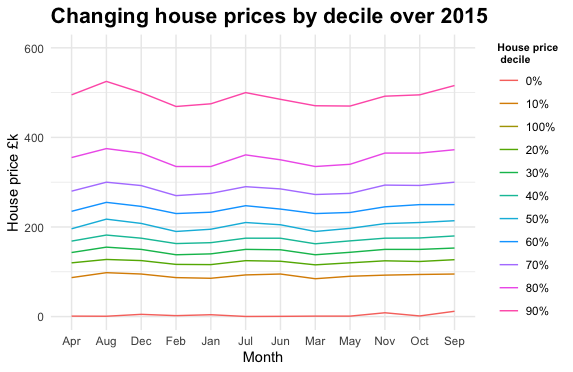

.

[output not shown]